# Context & Objectives

#### Correlation

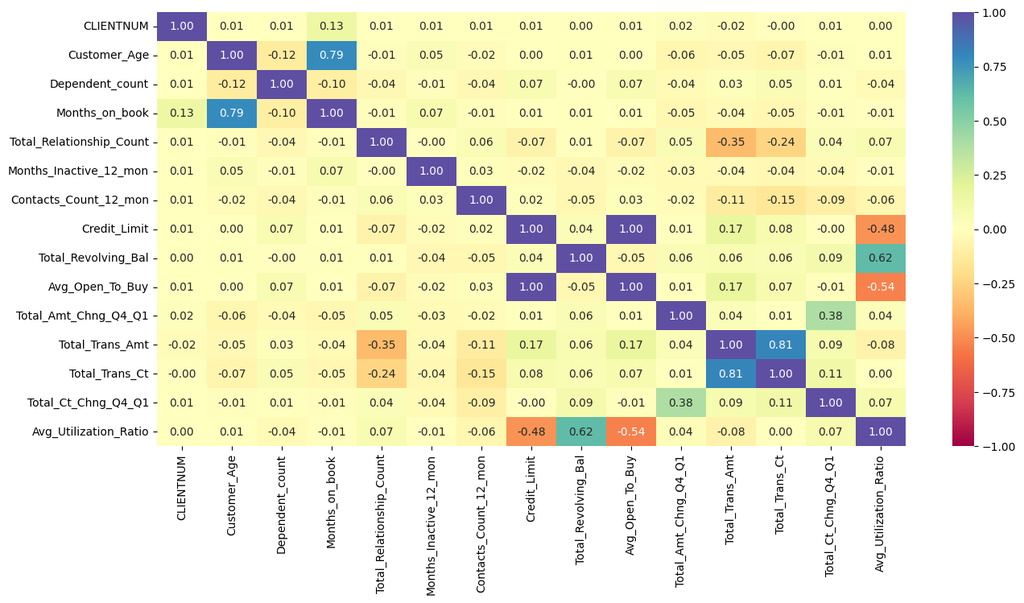

```python
# Computing correlation matrix
plt.figure(figsize=(15, 7))
sns.heatmap(data.corr(numeric_only=True), annot=True, vmin=-1, vmax=1, fmt=".2f", cmap="Spectral")
plt.show()
```

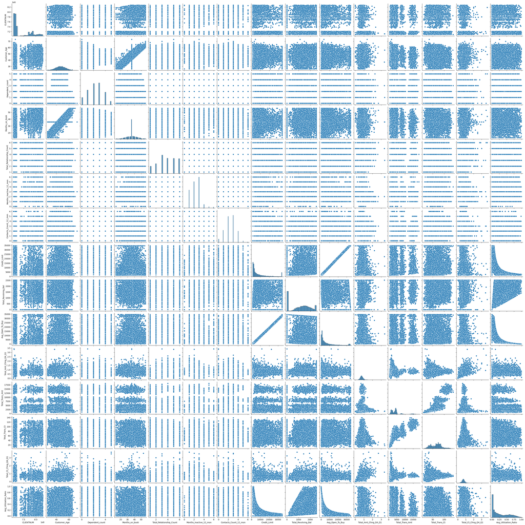

```python
sns.pairplot(data)
```

#### Attrition & Revolving Balance

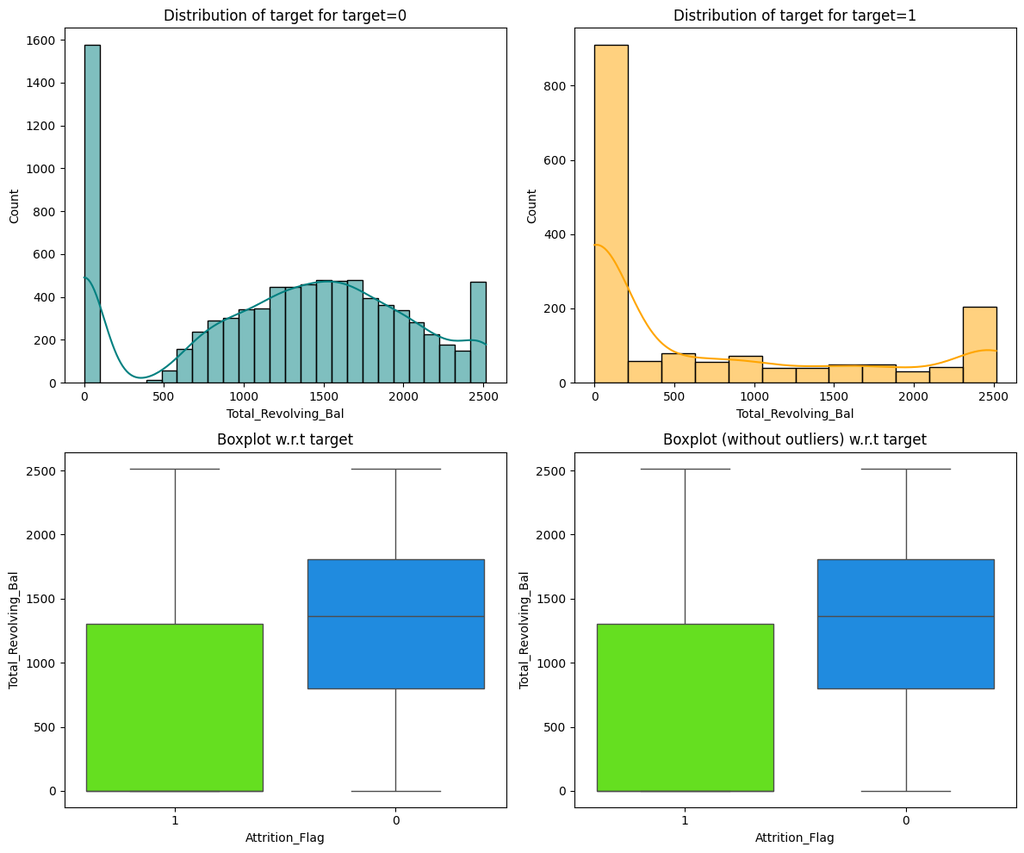

```python
# Creating a distribution of target plot
distribution_plot_wrt_target(data, "Total_Revolving_Bal", "Attrition_Flag")
```

- There's some denotation pointing to a higher rate of attrition amongst customers who have zero revolving balance and to a lower extent amongst those who seem to have the totality of their available credit.

#### Attrition & Credit Limit

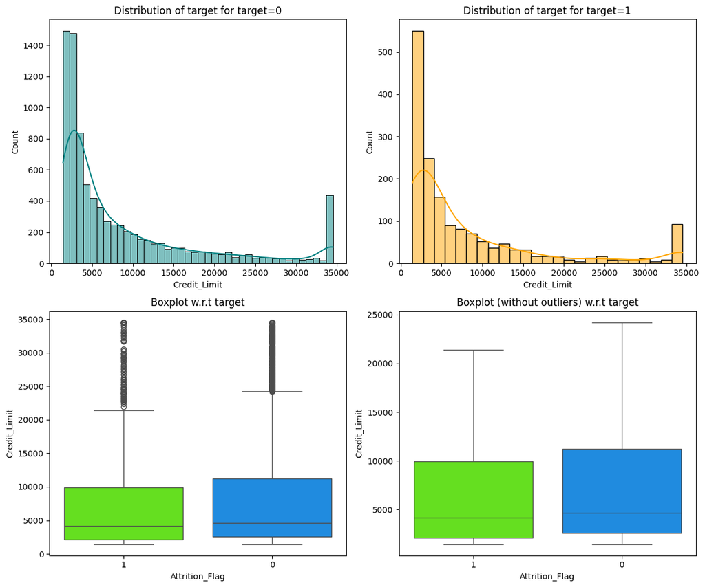

```python
# Creating a distribution of target plot
distribution_plot_wrt_target(data, "Credit_Limit", "Attrition_Flag")
```

#### Attrition & Age

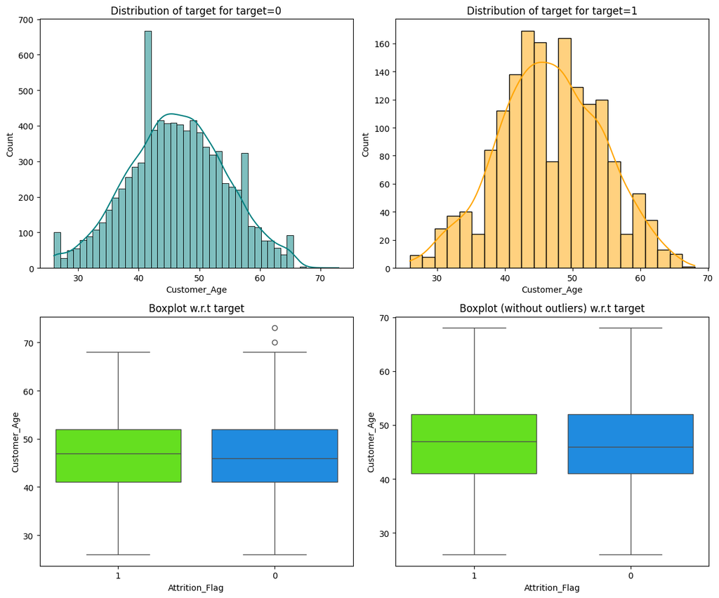

```python
# Creating a distribution of target plot
distribution_plot_wrt_target(data, "Customer_Age", "Attrition_Flag")
```

- The above analysis seems to denote an uptake in customer attrition between the ages of 40 and 55.

#### Attrition & Transaction Count

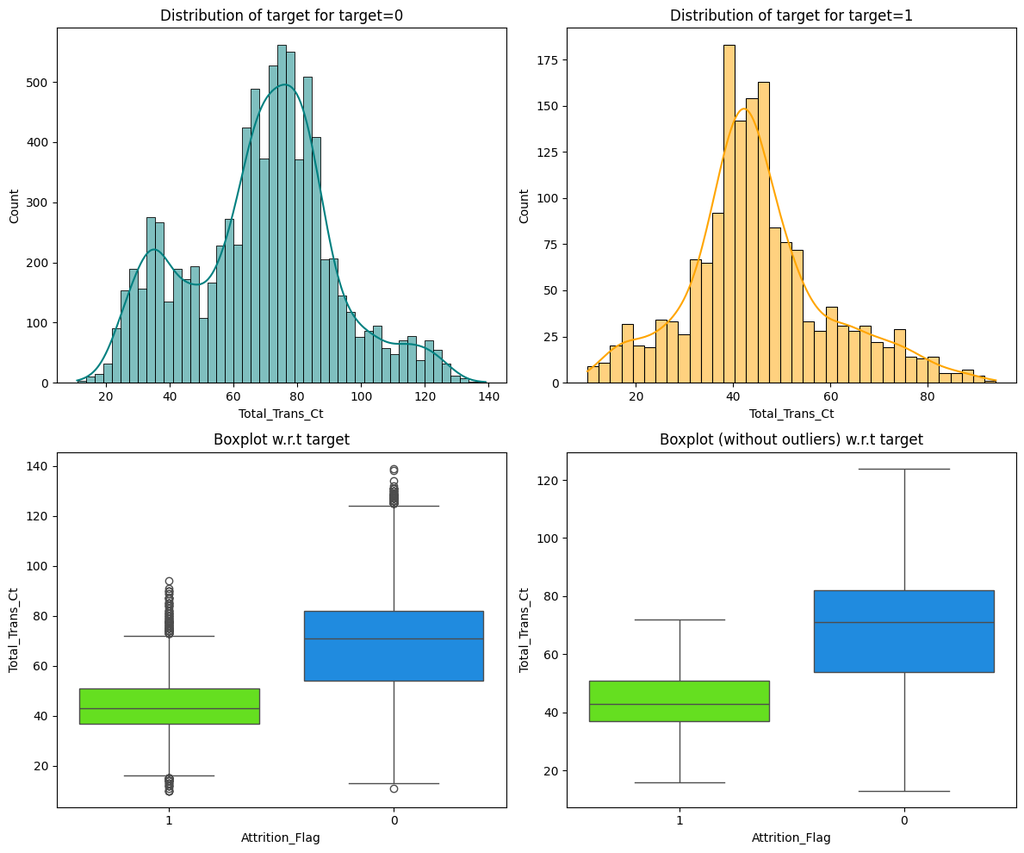

```python
# Creating a distribution of target plot
distribution_plot_wrt_target(data, "Total_Trans_Ct", "Attrition_Flag")
```

#### Attrition & Transaction Amount

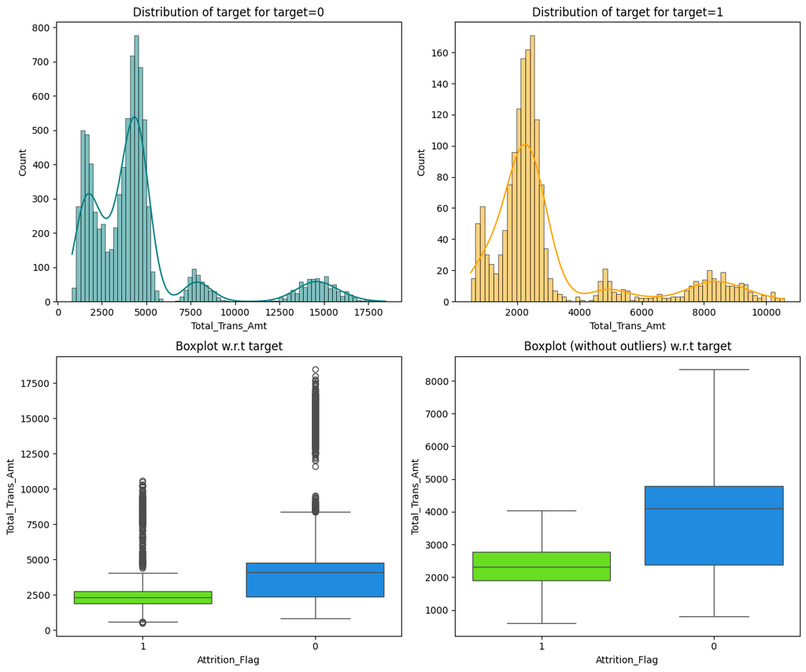

```python
# Creating a distribution of target plot
distribution_plot_wrt_target(data, "Total_Trans_Amt", "Attrition_Flag")
```

- There seems to be a slight denotation of higher attrition rates amongst those who have had transaction lower than 3500 USD.
- No attrition has been observed on those who have had transactions above 11k

#### Attrition & Ratio of Transaction Count (Q4 over Q1)

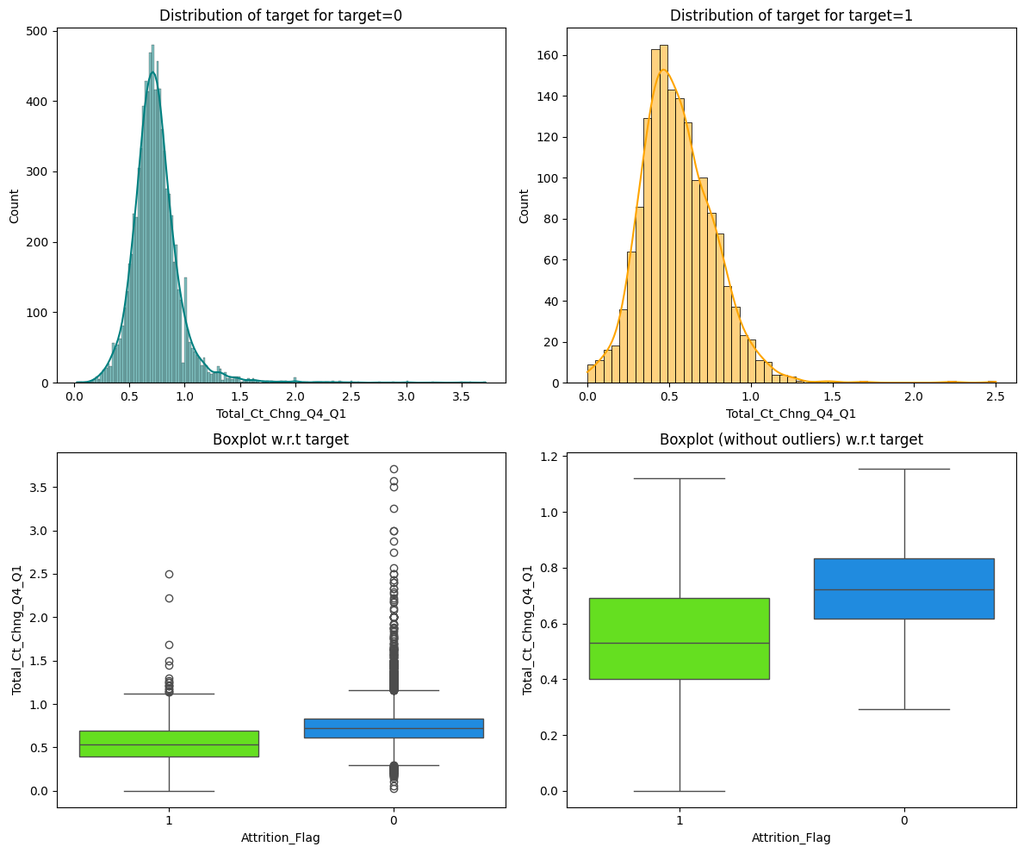

```python
# Creating a distribution of target plot
distribution_plot_wrt_target(data, "Total_Ct_Chng_Q4_Q1", "Attrition_Flag")
```

- The above analysis seems to denote that a slightly lower attrition rates appears to be more observable the closer the ratio transaction count is to 1.
- Slightly more attrition seems to be observed amongst those who have had 0 ratio transaction count, although not very significant.

#### Attrition & Ratio of Transaction Amount (Q4 over Q1)

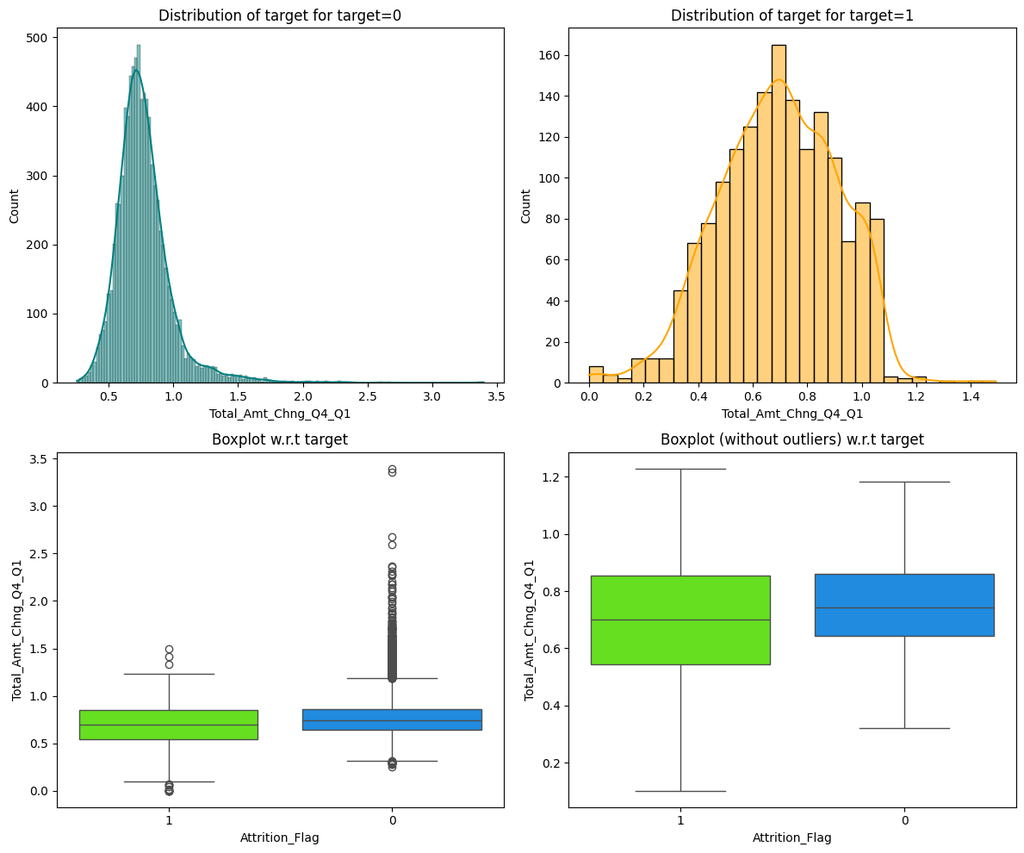

```python
# Creating a distribution of target plot
distribution_plot_wrt_target(data, "Total_Amt_Chng_Q4_Q1", "Attrition_Flag")
```

- The above analysis seem to indicate a somewhat lower attrition rate once the ratio transaction amount surpasses 1.1

#### Attrition & Avg. Utilization Ratio

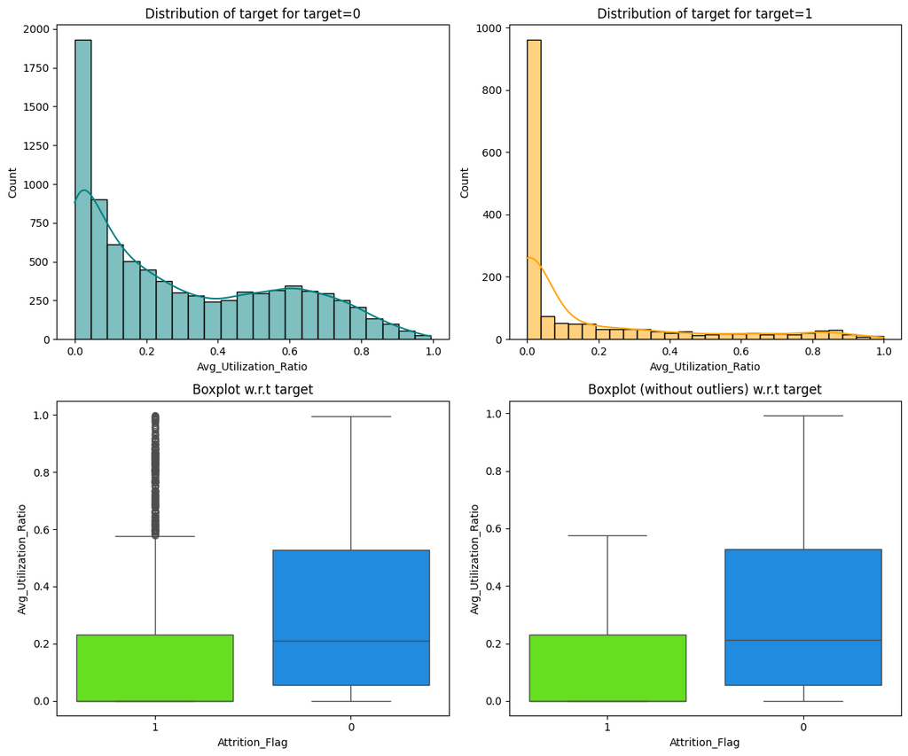

```python
# Creating a distribution of target plot
distribution_plot_wrt_target(data, "Avg_Utilization_Ratio", "Attrition_Flag")
```

- Attrition rate seems to be significantly higher in customer with 0 utilization rate against available credit.

#### Attrition & Months on Book

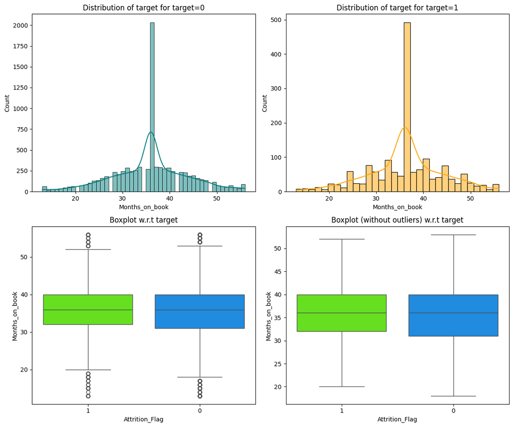

```python
# Creating a distribution of target plot
distribution_plot_wrt_target(data, "Months_on_book", "Attrition_Flag")
```

- The above analysis doesn't denote a very significant impact of the independent variable against the target variable with the distribution appearing proportional to the the one observed amongst existing customers.

#### Attrition & Avg. Open to Buy

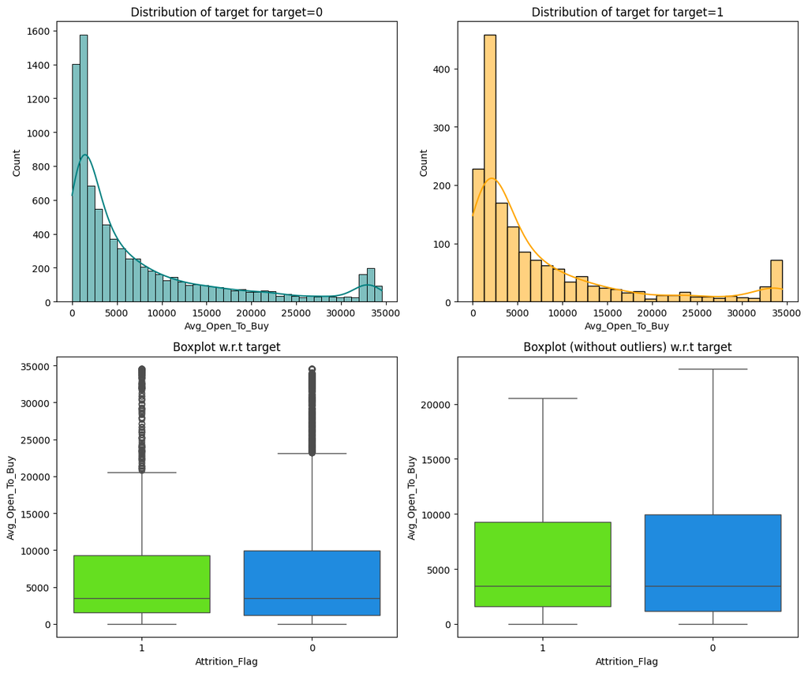

```python
# Creating a distribution of target plot
distribution_plot_wrt_target(data, "Avg_Open_To_Buy", "Attrition_Flag")
```

- The above analysis doesn't denote a very significant impact of the independent variable against the target variable with the distribution appearing proportional to the the one observed amongst existing customers.

# Data Preparation for Modelling

#### Dropping ID Column

```python
# verifying total number of values under CLIENTUM
data.CLIENTNUM.nunique()

# dropping CLIENTNUM column
data.drop(["CLIENTNUM"], axis=1, inplace=True)
```

We've verified 10127 total CLIENTNUM counts and have decided to drop it since it becomes unessential for the purpose of this exercise.

#### Outlier Detection

```python
# Filter numerical columns
numerical_data = data.select_dtypes(include=['float64', 'int64'])

# Calculate quantiles for numerical columns only
Q1 = numerical_data.quantile(0.25)  # To find the 25th percentile
Q3 = numerical_data.quantile(0.75)  # To find the 75th percentile

IQR = Q3 - Q1  # Interquartile Range (75th percentile - 25th percentile)

# Finding lower and upper bounds for all numerical values
lower = (Q1 - 1.5 * IQR)
upper = (Q3 + 1.5 * IQR)
```

```python
# checking the % outliers
((data.select_dtypes(include=["float64", "int64"]) < lower) | (data.select_dtypes(include=["float64", "int64"]) > upper)).sum() / len(data) * 100
```

```
Customer_Age               0.020
Dependent_count            0.000
Months_on_book             3.812
Total_Relationship_Count   0.000
Months_Inactive_12_mon     3.268
Contacts_Count_12_mon      6.211
Credit_Limit               9.717
Total_Revolving_Bal        0.000
Avg_Open_To_Buy            9.509
Total_Amt_Chng_Q4_Q1       3.910
Total_Trans_Amt            8.848
Total_Trans_Ct             0.020
Total_Ct_Chng_Q4_Q1        3.891
Avg_Utilization_Ratio      0.000
dtype: float64
```

The above analysis points to the following observations:

- `Customer_Age` outliers - 0.020%
- `Months_on_book` outliers - 3.8% *`Months_Inactive_12_mon` outliers - 3.2%
- `Contacts_Count_12_mon` outliers - 6.2%
- `Credit_Limit` outliers - 9.7%
- `Avg_Open_To_Buy` outliers - 9.5%
- `Total_Amt_Chng_Q4_Q1` outliers - 3.9%
- `Total_Trans_Amt` outliers - 8.8%
- `Total_Trans_Ct` outliers - 0.020%
- `Total_Ct_Chng_Q4_Q1` outliers - 3.9%
- We can observe quite a few outliers in the dataset across many of our columns
- After careful consideration around the nature of our data, the reason why these outliers exit, the value they provide and the type of model we're using for this project, we've decided to not perform any outlier treatment or transformation as we've determined these to be proper values.

#### Train/Validation/Test Split

```python
# creating the copy of the dataframe
data1 = data.copy()
```

```python
# replacing 'abc' values for NaN
data1["Income_Category"].replace("abc", np.nan, inplace=True)
```

```python
# validating that we've successfully replaced the anomalous values
data1.isna().sum()
```

```
Attrition_Flag                 0
Customer_Age                   0
Gender                         0
Dependent_count                0
Education_Level             1519
Marital_Status               749
Income_Category                0
Card_Category                  0
Months_on_book                 0
Total_Relationship_Count       0
Months_Inactive_12_mon         0
Contacts_Count_12_mon          0
Credit_Limit                   0
Total_Revolving_Bal            0
Avg_Open_To_Buy                0
Total_Amt_Chng_Q4_Q1           0
Total_Trans_Amt                0
Total_Trans_Ct                 0
Total_Ct_Chng_Q4_Q1            0
Avg_Utilization_Ratio          0
dtype: int64
```

```python
# creating an instace of the imputer to be used
imputer = SimpleImputer(strategy="most_frequent") #choosing 'most frequent' as it aligns more closely with the nature of this categorical columns
```

```python
# Dividing train data into X and y

X = data1.drop(["Attrition_Flag","Avg_Open_To_Buy"], axis=1)
y = data1["Attrition_Flag"]
```

- Dropping Avg_Open_To_Buy due to its perfect correlation with Credit_Limit to help mitigate multicolinearity in our model.

```python
# Splitting data into 80% train and 20% temporary set
X_train, X_temp, y_train, y_temp = train_test_split(X, y, test_size=0.2, random_state=5, stratify=y)

# Splitting temporary set into 75% test and 25% validation set
X_test, X_val, y_test, y_val = train_test_split(X_temp, y_temp, test_size=0.25, random_state=5, stratify=y_temp)

print(X_train.shape, X_val.shape, X_test.shape)
```

```
(8101, 18) (507, 18) (1519, 18)
```

#### Missing Value Imptutation

```python
# determining the missing value columns
reqd_col_for_impute = ["Education_Level", "Marital_Status", "Income_Category"]
```

```python
# Fitting and transforming the training data
X_train[reqd_col_for_impute] = imputer.fit_transform(X_train[reqd_col_for_impute])
# Transforming validation data
X_val[reqd_col_for_impute] = imputer.transform(X_val[reqd_col_for_impute])
# Transforming test data
X_test[reqd_col_for_impute] = imputer.transform(X_test[reqd_col_for_impute])
```

```python
# Checking that there are no missing values in both train, validation or test sets
print(X_train.isna().sum())
print("-" * 30)
print(X_val.isna().sum())
print("-" * 30)
print(X_test.isna().sum())
```

```
Customer_Age                0
Gender                      0
Dependent_count             0
Education_Level             0
Marital_Status              0
Income_Category             0
Card_Category               0
Months_on_book              0
Total_Relationship_Count    0
Months_Inactive_12_mon      0
Contacts_Count_12_mon       0
Credit_Limit                0
Total_Revolving_Bal         0
Total_Amt_Chng_Q4_Q1        0
Total_Trans_Amt             0
Total_Trans_Ct              0
Total_Ct_Chng_Q4_Q1         0
Avg_Utilization_Ratio       0
dtype: int64
------------------------------
Customer_Age                0
Gender                      0
Dependent_count             0
Education_Level             0
Marital_Status              0
Income_Category             0
Card_Category               0
Months_on_book              0
Total_Relationship_Count    0
Months_Inactive_12_mon      0
Contacts_Count_12_mon       0
Credit_Limit                0
Total_Revolving_Bal         0
Total_Amt_Chng_Q4_Q1        0
Total_Trans_Amt             0
Total_Trans_Ct              0
Total_Ct_Chng_Q4_Q1         0
Avg_Utilization_Ratio       0
dtype: int64
------------------------------
Customer_Age                0
Gender                      0
Dependent_count             0
Education_Level             0
Marital_Status              0
Income_Category             0
Card_Category               0
Months_on_book              0
Total_Relationship_Count    0
Months_Inactive_12_mon      0
Contacts_Count_12_mon       0
Credit_Limit                0
Total_Revolving_Bal         0
Total_Amt_Chng_Q4_Q1        0
Total_Trans_Amt             0
Total_Trans_Ct              0
Total_Ct_Chng_Q4_Q1         0
Avg_Utilization_Ratio       0
dtype: int64
```

```python
# printing the value count for each categorical column in train set
cols = X_train.select_dtypes(include=["object", "category"])
for i in cols.columns:
    print(X_train[i].value_counts())
    print("*" * 30)
```

```
Gender
F    4288
M    3813
Name: count, dtype: int64
Education_Level
Graduate         3707
High School      1613
Uneducated       1172
College           820
Post-Graduate     422
Doctorate         367
Name: count, dtype: int64
Marital_Status
Married     4395
Single      3119
Divorced     587
Name: count, dtype: int64
Income_Category
Less than $40K    2849
$40K - $60K       1420
$80K - $120K      1247
$60K - $80K       1121
Unknown            891
$120K +            573
Name: count, dtype: int64
Card_Category
Blue        7548
Silver       443
Gold          93
Platinum      17
Name: count, dtype: int64
```

```python
# printing the value count for each categorical column in validation set
cols = X_val.select_dtypes(include=["object", "category"])
for i in cols.columns:
    print(X_val[i].value_counts())
    print("*" * 30)
```

```
Gender
F    270
M    237
Name: count, dtype: int64
Education_Level
Graduate         251
High School       93
Uneducated        75
College           49
Post-Graduate     23
Doctorate         16
Name: count, dtype: int64
Marital_Status
Married     243
Single      211
Divorced     53
Name: count, dtype: int64
Income_Category
Less than $40K    183
$40K - $60K        79
$80K - $120K       79
$60K - $80K        71
Unknown            58
$120K +            37
Name: count, dtype: int64
Card_Category
Blue        465
Silver       33
Gold          7
Platinum      2
Name: count, dtype: int64
```

```python
# printing the value count for each categorical column in testing set
cols = X_test.select_dtypes(include=["object", "category"])
for i in cols.columns:
    print(X_test[i].value_counts())
    print("*" * 30)
```

```
Gender
F    800
M    719
Name: count, dtype: int64
Education_Level
Graduate         689
High School      307
Uneducated       240
College          144
Post-Graduate     71
Doctorate         68
Name: count, dtype: int64
Marital_Status
Married     798
Single      613
Divorced    108
Name: count, dtype: int64
Income_Category
Less than $40K    529
$40K - $60K       291
$60K - $80K       210
$80K - $120K      209
Unknown           163
$120K +           117
Name: count, dtype: int64
Card_Category
Blue        1423
Silver        79
Gold          16
Platinum       1
Name: count, dtype: int64
```

```python
# Checking class balance for whole data, train set, validation set, and test set

print("Target value ratio in y")
print(y.value_counts(1))
print("*" * 80)
print("Target value ratio in y_train")
print(y_train.value_counts(1))
print("*" * 80)
print("Target value ratio in y_val")
print(y_val.value_counts(1))
print("*" * 80)
print("Target value ratio in y_test")
print(y_test.value_counts(1))
print("*" * 80)
```

```
Target value ratio in y
Attrition_Flag
0   0.839
1   0.161
Name: proportion, dtype: float64
Target value ratio in y_train
Attrition_Flag
0   0.839
1   0.161
Name: proportion, dtype: float64
Target value ratio in y_val
Attrition_Flag
0   0.840
1   0.160
Name: proportion, dtype: float64
Target value ratio in y_test
Attrition_Flag
0   0.839
1   0.161
Name: proportion, dtype: float64
```

The class proportions in each set, including gender, education level, marital status, income category, and card category, appear to be consistent with the original dataset. This indicates that the stratification process was successful in preserving the class distribution during the splitting process. Additionally, the target value ratio for the 'Attrition_Flag' variable remains consistent across the training, validation, and test sets, with approximately 83.9% of entries labeled as 'Existing Customer' and 16.1% as 'Attrited Customer' in each set.

#### Encoding Categorical Variables

```python
# Initializing LabelEncoder
le = LabelEncoder()

# Encode target variable y_train
y_train = le.fit_transform(y_train)

# Encode target variable y_val
y_val = le.transform(y_val)
```

```python
# One-hot encoding creating dummy variables for categorical variables
X_train = pd.get_dummies(X_train, drop_first=True)
X_val = pd.get_dummies(X_val, drop_first=True)
X_test = pd.get_dummies(X_test, drop_first=True)
print(X_train.shape, X_val.shape, X_test.shape)
```

```
(8101, 29) (507, 29) (1519, 29)
```

```python
X_train.head()
```

|  | Customer_Age | Dependent_count | Months_on_book | Total_Relationship_Count | Months_Inactive_12_mon | Contacts_Count_12_mon | Credit_Limit | Total_Revolving_Bal | Total_Amt_Chng_Q4_Q1 | Total_Trans_Amt | Total_Trans_Ct | Total_Ct_Chng_Q4_Q1 | Avg_Utilization_Ratio | Gender_M | Education_Level_Doctorate | Education_Level_Graduate | Education_Level_High School | Education_Level_Post-Graduate | Education_Level_Uneducated | Marital_Status_Married | Marital_Status_Single | Income_Category_$40K - $60K | Income_Category_$60K - $80K | Income_Category_$80K - $120K | Income_Category_Less than $40K | Income_Category_Unknown | Card_Category_Gold | Card_Category_Platinum | Card_Category_Silver |
| --- | --- | --- | --- | --- | --- | --- | --- | --- | --- | --- | --- | --- | --- | --- | --- | --- | --- | --- | --- | --- | --- | --- | --- | --- | --- | --- | --- | --- | --- |
| 5298 | 54 | 3 | 36 | 5 | 1 | 4 | 3666.000 | 1739 | 0.779 | 4735 | 84 | 0.826 | 0.474 | False | False | False | True | False | False | True | False | False | False | False | True | False | False | False | False |
| 4037 | 53 | 1 | 36 | 3 | 2 | 4 | 4287.000 | 0 | 0.294 | 1635 | 41 | 0.242 | 0.000 | False | False | True | False | False | False | False | True | False | False | False | True | False | False | False | False |
| 33 | 53 | 2 | 38 | 5 | 2 | 3 | 2650.000 | 1490 | 1.750 | 1411 | 28 | 1.000 | 0.562 | False | False | False | False | False | False | True | False | False | False | False | True | False | False | False | False |
| 4051 | 51 | 2 | 43 | 6 | 2 | 3 | 2124.000 | 1426 | 0.966 | 3210 | 52 | 0.733 | 0.671 | False | False | False | False | False | True | True | False | False | False | False | True | False | False | False | False |
| 9495 | 32 | 0 | 25 | 2 | 3 | 0 | 8851.000 | 1753 | 0.627 | 14783 | 110 | 0.864 | 0.198 | False | False | False | True | False | False | False | False | False | False | False | True | False | False | False | False |

# Model Building

#### Model Evaluation Criterion

**Potential Wrong Prediction**

- Predicting a customer will attrite when in reality, they won't (FP)
- Predicting a customer will not attrite, when in reality they will (FN)

**What Scenario is most relevant to the business?**

- If we predict that a customer will not attrite when in reality they would, then the company would have suffered the loss of a customer

**How can we reduce the impact?** We want the recall to be maximized. The greater the recall score, the higher are the chances of minimizing False Negatives.

#### Model Functions

```python
# defining a function to compute different metrics to check performance of a classification model built using sklearn
def model_performance_classification_sklearn(model, predictors, target):
    """
    Function to compute different metrics to check classification model performance

    model: classifier
    predictors: independent variables
    target: dependent variable
    """

    # predicting using the independent variables
    pred = model.predict(predictors)

    acc = accuracy_score(target, pred)  # to compute Accuracy
    recall = recall_score(target, pred)  # to compute Recall
    precision = precision_score(target, pred)  # to compute Precision
    f1 = f1_score(target, pred)  # to compute F1-score

    # creating a dataframe of metrics
    df_perf = pd.DataFrame(
        {
            "Accuracy": acc,
            "Recall": recall,
            "Precision": precision,
            "F1": f1

        },
        index=[0],
    )

    return df_perf
```

```python
def confusion_matrix_sklearn(model, predictors, target):
    """
    To plot the confusion_matrix with percentages

    model: classifier
    predictors: independent variables
    target: dependent variable
    """
    y_pred = model.predict(predictors)
    cm = confusion_matrix(target, y_pred)
    labels = np.asarray(
        [
            ["{0:0.0f}".format(item) + "\n{0:.2%}".format(item / cm.flatten().sum())]
            for item in cm.flatten()
        ]
    ).reshape(2, 2)

    plt.figure(figsize=(6, 4))
    sns.heatmap(cm, annot=labels, fmt="")
    plt.ylabel("True label")
    plt.xlabel("Predicted label")
```

#### Model Building with Original Data

```python
models = []  # Empty list to store all the models

# Appending models into the list
models.append(("Bagging", BaggingClassifier(random_state=1)))
models.append(("Random forest", RandomForestClassifier(random_state=1)))
models.append(("AdaBoost", AdaBoostClassifier(random_state=1)))
models.append(("Gradient Boosting", GradientBoostingClassifier(random_state=1)))
models.append(("XGBoost", XGBClassifier(random_state=1)))

# Training Performance
print("\n" "Training Performance:" "\n")
for name, model in models:
    model.fit(X_train, y_train)
    scores = recall_score(y_train, model.predict(X_train))
    print("{}: {}".format(name, scores))

# Validation Performance
print("\n" "Validation Performance:" "\n")
for name, model in models:
    model.fit(X_train, y_train)
    scores_val = recall_score(y_val, model.predict(X_val))
    print("{}: {}".format(name, scores_val))
```

```
Training Performance:

Bagging: 0.989247311827957
Random forest: 1.0
AdaBoost: 0.8625192012288786
Gradient Boosting: 0.890937019969278
XGBoost: 1.0

Validation Performance:

Bagging: 0.7901234567901234
Random forest: 0.8024691358024691
AdaBoost: 0.8148148148148148
Gradient Boosting: 0.8395061728395061
XGBoost: 0.9012345679012346
```

```python
print("\nTraining and Validation Performance Difference:\n")

for name, model in models:
    model.fit(X_train, y_train)
    scores_train = recall_score(y_train, model.predict(X_train))
    scores_val = recall_score(y_val, model.predict(X_val))
    difference_org = scores_train - scores_val
    print("{}: Training Score: {:.4f}, Validation Score: {:.4f}, difference_org: {:.4f}".format(name, scores_train, scores_val, difference_org))
```

```
Training and Validation Performance Difference:

Bagging: Training Score: 0.9892, Validation Score: 0.7901, difference_org: 0.1991
Random forest: Training Score: 1.0000, Validation Score: 0.8025, difference_org: 0.1975
AdaBoost: Training Score: 0.8625, Validation Score: 0.8148, difference_org: 0.0477
Gradient Boosting: Training Score: 0.8909, Validation Score: 0.8395, difference_org: 0.0514
XGBoost: Training Score: 1.0000, Validation Score: 0.9012, difference_org: 0.0988
```

Based on the provided output, the top three models, considering the validation performance and the difference between training and validation scores, are as follows:

- XGBoost - Training Score: 1.0000 Validation Score: 0.9012 Difference: 0.0988
- Gradient Boosting - Training Score: 0.8909 Validation Score: 0.8395 Difference: 0.0514
- AdaBoost - Training Score: 0.8625 Validation Score: 0.8148 Difference: 0.0477

#### Model Building with Oversampled Data

```python
sm = SMOTE(
    sampling_strategy=1, k_neighbors=5, random_state=1
)  # Synthetic Minority Over Sampling Technique
X_train_over, y_train_over = sm.fit_resample(X_train, y_train)
```

```python
print("Before Oversampling, counts of label 'Yes': {}".format(sum(y_train == 1)))
print("Before Oversampling, counts of label 'No': {} \n".format(sum(y_train == 0)))

print("After Oversampling, counts of label 'Yes': {}".format(sum(y_train_over == 1)))
print("After Oversampling, counts of label 'No': {} \n".format(sum(y_train_over == 0)))


print("After Oversampling, the shape of train_X: {}".format(X_train_over.shape))
print("After Oversampling, the shape of train_y: {} \n".format(y_train_over.shape))
```

```
Before Oversampling, counts of label 'Yes': 1302
Before Oversampling, counts of label 'No': 6799

After Oversampling, counts of label 'Yes': 6799
After Oversampling, counts of label 'No': 6799

After Oversampling, the shape of train_X: (13598, 29)
After Oversampling, the shape of train_y: (13598,)
```

```python
models = []  # Empty list to store all the models

# Appending models into the list
models.append(("Bagging", BaggingClassifier(random_state=1)))
models.append(("Random forest", RandomForestClassifier(random_state=1)))
models.append(("AdaBoost", AdaBoostClassifier(random_state=1)))
models.append(("Gradient Boosting", GradientBoostingClassifier(random_state=1)))
models.append(("XGBoost", XGBClassifier(random_state=1)))


print("\n" "Training Performance:" "\n")
for name, model in models:
    model.fit(X_train_over, y_train_over)
    scores = recall_score(y_train_over, model.predict(X_train_over))
    print("{}: {}".format(name, scores))

print("\n" "Validation Performance:" "\n")
for name, model in models:
    model.fit(X_train_over, y_train_over)
    scores = recall_score(y_val, model.predict(X_val))
    print("{}: {}".format(name, scores))
```

```
Training Performance:

Bagging: 0.9986762759229298
Random forest: 1.0
AdaBoost: 0.9692601853213708
Gradient Boosting: 0.9792616561259009
XGBoost: 1.0

Validation Performance:

Bagging: 0.8641975308641975
Random forest: 0.8765432098765432
AdaBoost: 0.8518518518518519
Gradient Boosting: 0.9012345679012346
XGBoost: 0.9259259259259259
```

```python
print("\nTraining and Validation Performance Difference:\n")

for name, model in models:
    model.fit(X_train_over, y_train_over)
    scores_train = recall_score(y_train_over, model.predict(X_train_over))
    scores_val = recall_score(y_val, model.predict(X_val))
    difference_over = scores_train - scores_val
    print("{}: Training Score: {:.4f}, Validation Score: {:.4f}, difference_over: {:.4f}".format(name, scores_train, scores_val, difference_over))
```

```
Training and Validation Performance Difference:

Bagging: Training Score: 0.9987, Validation Score: 0.8642, difference_over: 0.1345
Random forest: Training Score: 1.0000, Validation Score: 0.8765, difference_over: 0.1235
AdaBoost: Training Score: 0.9693, Validation Score: 0.8519, difference_over: 0.1174
Gradient Boosting: Training Score: 0.9793, Validation Score: 0.9012, difference_over: 0.0780
XGBoost: Training Score: 1.0000, Validation Score: 0.9259, difference_over: 0.0741
```

Based on the provided output, the top three models, considering the validation performance and the difference between training and validation scores, are as follows:

- XGBoost - Training Score: 1.0000 Validation Score: 0.9259 Difference: 0.0741
- Gradient Boosting - Training Score: 0.9793 Validation Score: 0.9012 Difference: 0.0780
- Random Forest - Training Score: 1.0000 Validation Score: 0.8765 Difference: 0.1235

#### Model Building with Undersampled Data

```python
rus = RandomUnderSampler(random_state=1)
X_train_un, y_train_un = rus.fit_resample(X_train, y_train)
```

```python
print("Before Under Sampling, counts of label 'Yes': {}".format(sum(y_train == 1)))
print("Before Under Sampling, counts of label 'No': {} \n".format(sum(y_train == 0)))

print("After Under Sampling, counts of label 'Yes': {}".format(sum(y_train_un == 1)))
print("After Under Sampling, counts of label 'No': {} \n".format(sum(y_train_un == 0)))

print("After Under Sampling, the shape of train_X: {}".format(X_train_un.shape))
print("After Under Sampling, the shape of train_y: {} \n".format(y_train_un.shape))
```

```
Before Under Sampling, counts of label 'Yes': 1302
Before Under Sampling, counts of label 'No': 6799

After Under Sampling, counts of label 'Yes': 1302
After Under Sampling, counts of label 'No': 1302

After Under Sampling, the shape of train_X: (2604, 29)
After Under Sampling, the shape of train_y: (2604,)
```

```python
models = []  # Empty list to store all the models

# Appending models into the list
models.append(("Bagging", BaggingClassifier(random_state=1)))
models.append(("Random forest", RandomForestClassifier(random_state=1)))
models.append(("AdaBoost", AdaBoostClassifier(random_state=1)))
models.append(("Gradient Boosting", GradientBoostingClassifier(random_state=1)))
models.append(("XGBoost", XGBClassifier(random_state=1)))


print("\n" "Training Performance:" "\n")
for name, model in models:
    model.fit(X_train_un, y_train_un)
    scores = recall_score(y_train_un, model.predict(X_train_un))
    print("{}: {}".format(name, scores))

print("\n" "Validation Performance:" "\n")
for name, model in models:
    model.fit(X_train_un, y_train_un)
    scores = recall_score(y_val, model.predict(X_val))
    print("{}: {}".format(name, scores))
```

```
Training Performance:

Bagging: 0.9961597542242704
Random forest: 1.0
AdaBoost: 0.9539170506912442
Gradient Boosting: 0.9861751152073732
XGBoost: 1.0

Validation Performance:

Bagging: 0.9135802469135802
Random forest: 0.9382716049382716
AdaBoost: 0.9382716049382716
Gradient Boosting: 0.9259259259259259
XGBoost: 0.9259259259259259
```

```python
print("\nTraining and Validation Performance Difference:\n")

for name, model in models:
    model.fit(X_train_un, y_train_un)
    scores_train = recall_score(y_train_un, model.predict(X_train_un))
    scores_val = recall_score(y_val, model.predict(X_val))
    difference_un = scores_train - scores_val
    print("{}: Training Score: {:.4f}, Validation Score: {:.4f}, difference_un: {:.4f}".format(name, scores_train, scores_val, difference_un))
```

```
Training and Validation Performance Difference:

Bagging: Training Score: 0.9962, Validation Score: 0.9136, difference_un: 0.0826
Random forest: Training Score: 1.0000, Validation Score: 0.9383, difference_un: 0.0617
AdaBoost: Training Score: 0.9539, Validation Score: 0.9383, difference_un: 0.0156
Gradient Boosting: Training Score: 0.9862, Validation Score: 0.9259, difference_un: 0.0602
XGBoost: Training Score: 1.0000, Validation Score: 0.9259, difference_un: 0.0741
```

Based on the provided output, the top three models, considering the validation performance and the difference between training and validation scores, are as follows:

- Random Forest - Training Score: 1.0000 Validation Score: 0.9383 Difference: 0.0617
- AdaBoost - Training Score: 0.9539 Validation Score: 0.9383 Difference: 0.0156
- Gradient Boosting - Training Score: 0.9862 Validation Score: 0.9259 Difference: 0.0602

# Hyperparameter Tuning

After building 15 models, it was observed that the following models exhibited strong performance on both training and validation datasets:

- AdaBoost (UnderSampled Data)
- Random forest (UnderSampled Data)
- Gradient Boosting (UnderSampled Data)
- XGBoost: (OverSampled Data)

```python
%%time

# Defining model
tuned_ab1 = AdaBoostClassifier(random_state=1)

# Parameter grid to pass in RandomSearchCV
param_grid = {
    "n_estimators": np.arange(50,110,25),
    "learning_rate": [0.01,0.1,0.05],
    "base_estimator": [
        DecisionTreeClassifier(max_depth=2, random_state=1),
        DecisionTreeClassifier(max_depth=3, random_state=1),
    ],
}
# Type of scoring used to compare parameter combinations
scorer = metrics.make_scorer(metrics.recall_score)

# Calling RandomizedSearchCV
randomized_cv = RandomizedSearchCV(estimator=tuned_ab1,
                                   param_distributions=param_grid,
                                   n_iter=50,
                                   scoring=scorer,
                                   cv=5,
                                   random_state=1,
                                   n_jobs=-1)

# Fitting parameters in RandomizedSearchCV
randomized_cv.fit(X_train, y_train)

print("Best parameters are {} with CV score={}:".format(randomized_cv.best_params_, randomized_cv.best_score_))
```

```
Best parameters are {'n_estimators': 100, 'learning_rate': 0.1, 'base_estimator': DecisionTreeClassifier(max_depth=3, random_state=1)} with CV score=0.8594341290893015:
CPU times: user 4.89 s, sys: 472 ms, total: 5.36 s
Wall time: 3min 3s
```

##### Model Performance on Training Data

```python
# building model with best parameters
tuned_ab1 = AdaBoostClassifier(
    random_state=1,
    n_estimators=100,
    base_estimator=DecisionTreeClassifier(max_depth=3, random_state=1)
)

# Fit the model on training data
tuned_ab1.fit(X_train, y_train)
```

```
AdaBoostClassifier(base_estimator=DecisionTreeClassifier(max_depth=3,
                                                         random_state=1),
                   n_estimators=100, random_state=1)
```

```python
# Checking performance on training set
tuned_ab1_train = model_performance_classification_sklearn(
    tuned_ab1, X_train, y_train
)
print("Training performance:")
tuned_ab1_train
```

```
Training performance:
```

|  | Accuracy | Recall | Precision | F1 |
| --- | --- | --- | --- | --- |
| 0 | 1.000 | 1.000 | 1.000 | 1.000 |

##### Model Performance on Validation Data

```python
# Checking performance on validation set
tuned_ab1_val = model_performance_classification_sklearn(tuned_ab1, X_val, y_val)

print("Validation performance:")
tuned_ab1_val
```

```
Validation performance:
```

|  | Accuracy | Recall | Precision | F1 |
| --- | --- | --- | --- | --- |
| 0 | 0.964 | 0.901 | 0.880 | 0.890 |

```
Classification Report for Gradient Boosting Model on Validation Set:
              precision    recall  f1-score   support

           0       0.98      0.98      0.98       426
           1       0.88      0.90      0.89        81

    accuracy                           0.96       507
   macro avg       0.93      0.94      0.93       507
weighted avg       0.96      0.96      0.96       507
```

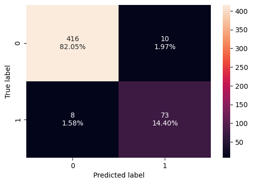

```python
# creating confusion matrix for Gradient Boosting Model
confusion_matrix_sklearn(tuned_ab1, X_val, y_val)

print() #introducing a break

# classification report
ab1_x_val = tuned_ab1.predict(X_val)
classification_report_val = classification_report(y_val, ab1_x_val)

# Print classification report for validation set
print("Classification Report for Gradient Boosting Model on Validation Set:")
print(classification_report_val)
```

**Observations**

Recall: The model achieves a recall of 98% for class 0 and 90% for class 1. This means that the model correctly identifies 98% of existing customers and 90% of attrited customers.

Precision: The model achieves a high precision of 98% for class 0 (Existing Customer) and 88% for class 1 (Attrited Customer). This indicates that when the model predicts a customer to belong to a certain class, it is correct 98% of the time for class 0 and 88% of the time for class 1.

F1-score: The F1-score is the harmonic mean of precision and recall, providing a balance between the two metrics. The model achieves an F1-score of 0.98 for class 0 and 0.89 for class 1.

Accuracy: The overall accuracy of the model on the validation set is 96%. This indicates the proportion of correctly classified instances out of all instances.

Overall, the model demonstrates strong performance on the validation set, with high precision, recall, and F1-score for both classes. However, it's essential to consider these metrics in the context of the specific business requirements and the relative importance of precision and recall for the given task.

```python
%%time

# Defining model
tuned_rf1 = RandomForestClassifier(random_state=1)

# Parameter grid to pass in RandomSearchCV
param_grid = {
    "n_estimators": [50,110,25],
    "min_samples_leaf": np.arange(1, 4),
    "max_features": [np.arange(0.3, 0.6, 0.1),'sqrt'],
    "max_samples": np.arange(0.4, 0.7, 0.1)
}

# Type of scoring used to compare parameter combinations
scorer = metrics.make_scorer(metrics.recall_score)

# Calling RandomizedSearchCV
randomized_cv = RandomizedSearchCV(estimator=tuned_rf1,
                                   param_distributions=param_grid,
                                   n_iter=50,
                                   scoring=scorer,
                                   cv=5,
                                   random_state=1,
                                   n_jobs=-1)

# Fitting parameters in RandomizedSearchCV
randomized_cv.fit(X_train, y_train)

print("Best parameters are {} with CV score={}:".format(randomized_cv.best_params_, randomized_cv.best_score_))
```

```
Best parameters are {'n_estimators': 25, 'min_samples_leaf': 2, 'max_samples': 0.6, 'max_features': 'sqrt'} with CV score=0.7657530209254346:
CPU times: user 1.83 s, sys: 245 ms, total: 2.07 s
Wall time: 1min 12s
```

##### Model Performance on Training Data

```python
# Creating a new pipeline containing the best parameters
tuned_rf1 = RandomForestClassifier(
    max_features='sqrt',
    random_state=1,
    n_estimators=25,
    min_samples_leaf=2,
    max_samples=0.6
)

# Fit the model on training data
tuned_rf1.fit(X_train, y_train)
```

```
RandomForestClassifier(max_samples=0.6, min_samples_leaf=2, n_estimators=25,
                       random_state=1)
```

```python
# Checking performance on training set
tuned_rf1_train = model_performance_classification_sklearn(
    tuned_rf1, X_train, y_train
)
print("Training performance:")
tuned_rf1_train
```

```
Training performance:
```

|  | Accuracy | Recall | Precision | F1 |
| --- | --- | --- | --- | --- |
| 0 | 0.986 | 0.927 | 0.982 | 0.954 |

##### Model Performance on Validation Data

```python
# Checking performance on validation set
tuned_rf1_val = model_performance_classification_sklearn(tuned_rf1, X_val, y_val)
print("Validation performance:")
tuned_rf1_val
```

```
Validation performance:
```

|  | Accuracy | Recall | Precision | F1 |
| --- | --- | --- | --- | --- |
| 0 | 0.947 | 0.778 | 0.875 | 0.824 |

```
Classification Report for Gradient Boosting Model on Validation Set:
              precision    recall  f1-score   support

           0       0.96      0.98      0.97       426
           1       0.88      0.78      0.82        81

    accuracy                           0.95       507
   macro avg       0.92      0.88      0.90       507
weighted avg       0.95      0.95      0.95       507
```

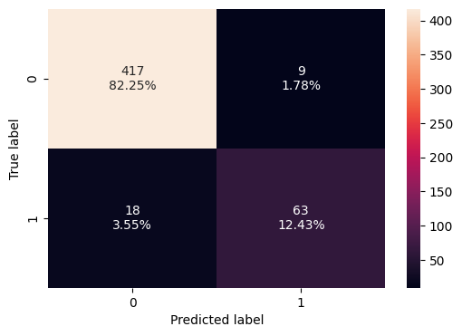

```python
# creating confusion matrix for Gradient Boosting Model
confusion_matrix_sklearn(tuned_rf1, X_val, y_val)

print() #introducing a break

# classification report
rf1_x_val = tuned_rf1.predict(X_val)
classification_report_val = classification_report(y_val, rf1_x_val)

# Print classification report for validation set
print("Classification Report for Gradient Boosting Model on Validation Set:")
print(classification_report_val)
```

**Observations**

Precision and Recall: In the first classification report, the precision and recall for class 1 (Attrited Customer) were higher (Precision: 0.88, Recall: 0.90) compared to the second classification report (Precision: 0.88, Recall: 0.78). This indicates that in the first scenario, the model was better at correctly identifying attrited customers while maintaining a high level of precision. F1-score:

The F1-score for class 1 (Attrited Customer) is lower in the second classification report (F1-score: 0.82) compared to the first classification report (F1-score: 0.89). This suggests that the model's performance in terms of both precision and recall for the attrited customer class decreased slightly in the second scenario. Accuracy:

The overall accuracy remains relatively stable between the two scenarios, with a slight decrease in the second scenario (from 96% to 95%). This indicates that while the model's performance in identifying attrited customers may have decreased slightly, its overall classification accuracy remains high.

In summary, while the model's performance in identifying attrited customers slightly decreased in the second scenario, its overall accuracy remained high. Further investigation and possibly model tuning may be needed to improve performance on the attrited customer class without compromising overall accuracy.

```python
%%time

# Defining model
tuned_gbm1 = GradientBoostingClassifier(random_state=1)

# Parameter grid to pass in RandomSearchCV
param_grid = {
    "init": [AdaBoostClassifier(random_state=1), DecisionTreeClassifier(random_state=1)],
    "n_estimators": np.arange(50, 110, 25),
    "learning_rate": [0.01, 0.1, 0.05],
    "subsample": [0.7, 0.9],
    "max_features": [0.5, 0.7, 1, 'sqrt'],
}

# Type of scoring used to compare parameter combinations
scorer = metrics.make_scorer(metrics.recall_score)

# Calling RandomizedSearchCV
randomized_cv = RandomizedSearchCV(estimator=tuned_gbm1,
                                   param_distributions=param_grid,
                                   n_iter=50,
                                   scoring=scorer,
                                   cv=5,
                                   random_state=1,
                                   n_jobs=-1)

# Fitting parameters in RandomizedSearchCV
randomized_cv.fit(X_train, y_train)

print("Best parameters are {} with CV score={}:".format(randomized_cv.best_params_, randomized_cv.best_score_))
```

```
Best parameters are {'subsample': 0.9, 'n_estimators': 100, 'max_features': 0.7, 'learning_rate': 0.1, 'init': AdaBoostClassifier(random_state=1)} with CV score=0.8494812849985264:
CPU times: user 5.57 s, sys: 483 ms, total: 6.05 s
Wall time: 3min 57s
```

##### Model Performance on Training Data

```python
# Creating a new pipeline containing the best parameters
tuned_gbm1 = GradientBoostingClassifier(
    max_features=0.7,
    init=AdaBoostClassifier(random_state=1),
    random_state=1,
    learning_rate=0.1,
    n_estimators=100,
    subsample=0.9,
)

# Fit the model on training data
tuned_gbm1.fit(X_train, y_train)
```

```
GradientBoostingClassifier(init=AdaBoostClassifier(random_state=1),
                           max_features=0.7, random_state=1, subsample=0.9)
```

```python
# Checking performance on training set
tuned_gbm1_train = model_performance_classification_sklearn(
    tuned_gbm1, X_train, y_train
)
print("Training performance:")
tuned_gbm1_train
```

```
Training performance:
```

|  | Accuracy | Recall | Precision | F1 |
| --- | --- | --- | --- | --- |
| 0 | 0.977 | 0.890 | 0.963 | 0.925 |

##### Model Performance on Validation Data

```python
# Checking performance on validation set
tuned_gbm1_val = model_performance_classification_sklearn(tuned_gbm1, X_val, y_val)
print("Validation performance:")
tuned_gbm1_val
```

```
Validation performance:
```

|  | Accuracy | Recall | Precision | F1 |
| --- | --- | --- | --- | --- |
| 0 | 0.957 | 0.840 | 0.883 | 0.861 |

```
Classification Report for Gradient Boosting Model on Validation Set:
              precision    recall  f1-score   support

           0       0.97      0.98      0.97       426
           1       0.88      0.84      0.86        81

    accuracy                           0.96       507
   macro avg       0.93      0.91      0.92       507
weighted avg       0.96      0.96      0.96       507
```

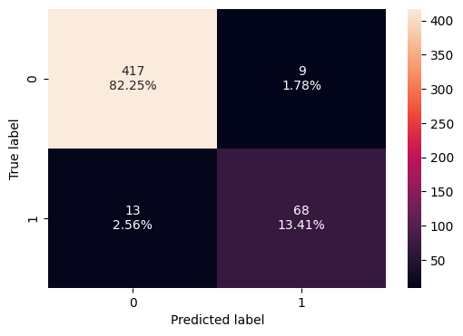

```python
# creating confusion matrix for Gradient Boosting Model
confusion_matrix_sklearn(tuned_gbm1, X_val, y_val)

print() #introducing a break

# classification report
gbm1_x_val = tuned_gbm1.predict(X_val)
classification_report_val = classification_report(y_val, gbm1_x_val)

# Print classification report for validation set
print("Classification Report for Gradient Boosting Model on Validation Set:")
print(classification_report_val)
```

**Observations**

The precision for class 1 (Attrited Customer) in this scenario is 0.88, which is consistent with the precision in the previous scenarios. This indicates that the model maintains a relatively high level of precision in identifying attrited customers across all scenarios. F1-score:

The F1-score for class 1 (Attrited Customer) is 0.86 in this scenario, which is higher compared to the second scenario (F1-score: 0.82) but slightly lower than the first scenario (F1-score: 0.89). This suggests an improvement in the model's ability to balance precision and recall for the attrited customer class compared to the second scenario. Accuracy:

In summary, while the recall for identifying attrited customers improved in this scenario compared to the second scenario, it remains slightly lower than the first scenario. However, the model maintains a high level of precision and overall accuracy across all scenarios, indicating its robustness in classifying both classes. Further model tuning and evaluation may be necessary to optimize performance, particularly in correctly identifying attrited customers.

```python
%%time

# Defining model
tuned_xgb1 = XGBClassifier(random_state=1)

# Parameter grid to pass in RandomSearchCV
param_grid={'n_estimators':np.arange(50,110,25),
            'scale_pos_weight':[1,2,5],
            'learning_rate':[0.01,0.1,0.05],
            'gamma':[1,3],
            'subsample':[0.7,0.9]
}

# Type of scoring used to compare parameter combinations
scorer = metrics.make_scorer(metrics.recall_score)

# Calling RandomizedSearchCV
randomized_cv = RandomizedSearchCV(estimator=tuned_xgb1,
                                   param_distributions=param_grid,
                                   n_iter=50,
                                   scoring=scorer,
                                   cv=5,
                                   random_state=1,
                                   n_jobs=-1)

# Fitting parameters in RandomizedSearchCV
randomized_cv.fit(X_train, y_train)

print("Best parameters are {} with CV score={}:".format(randomized_cv.best_params_, randomized_cv.best_score_))
```

```
Best parameters are {'subsample': 0.7, 'scale_pos_weight': 5, 'n_estimators': 75, 'learning_rate': 0.05, 'gamma': 3} with CV score=0.9370173887415267:
CPU times: user 2.27 s, sys: 249 ms, total: 2.52 s
Wall time: 1min 10s
```

##### Model Performance on Training Data

```python
# building model with best parameters
tuned_xgb1 = XGBClassifier(
    random_state=1,
    n_estimators=75,
    scale_pos_weight=5,
    subsample=0.7,
    learning_rate=0.05,
    gamma=3,
)

# Fit the model on training data
tuned_xgb1.fit(X_train, y_train)
```

```
XGBClassifier(base_score=None, booster=None, callbacks=None,
              colsample_bylevel=None, colsample_bynode=None,
              colsample_bytree=None, device=None, early_stopping_rounds=None,
              enable_categorical=False, eval_metric=None, feature_types=None,
              gamma=3, grow_policy=None, importance_type=None,
              interaction_constraints=None, learning_rate=0.05, max_bin=None,
              max_cat_threshold=None, max_cat_to_onehot=None,
              max_delta_step=None, max_depth=None, max_leaves=None,
              min_child_weight=None, missing=nan, monotone_constraints=None,
              multi_strategy=None, n_estimators=75, n_jobs=None,
              num_parallel_tree=None, random_state=1, ...)
```

```python
# Checking performance on training set
tuned_xgb1_train = model_performance_classification_sklearn(
    tuned_xgb1, X_train, y_train
)
print("Training performance:")
tuned_xgb1_train
```

```
Training performance:
```

|  | Accuracy | Recall | Precision | F1 |
| --- | --- | --- | --- | --- |
| 0 | 0.974 | 0.988 | 0.869 | 0.925 |

##### Model Performance on Validation Data

```python
# Checking performance on validation set
tuned_xgb1_val = model_performance_classification_sklearn(tuned_xgb1, X_val, y_val)

print("Validation performance:")
tuned_xgb1_val
```

```
Validation performance:
```

|  | Accuracy | Recall | Precision | F1 |
| --- | --- | --- | --- | --- |
| 0 | 0.939 | 0.914 | 0.755 | 0.827 |

```
Classification Report for Gradient Boosting Model on Validation Set:
              precision    recall  f1-score   support

           0       0.98      0.94      0.96       426
           1       0.76      0.91      0.83        81

    accuracy                           0.94       507
   macro avg       0.87      0.93      0.89       507
weighted avg       0.95      0.94      0.94       507
```

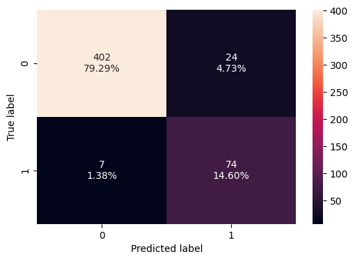

```python
# creating confusion matrix for Gradient Boosting Model
confusion_matrix_sklearn(tuned_xgb1, X_val, y_val)

print() #introducing a break

# classification report
xgb1_x_val = tuned_xgb1.predict(X_val)
classification_report_val = classification_report(y_val, xgb1_x_val)

# Print classification report for validation set
print("Classification Report for Gradient Boosting Model on Validation Set:")
print(classification_report_val)
```

**Observations**

Recall: In this classification report, the recall for class 1 (Attrited Customer) is 0.91, which is higher compared to the previous scenarios. This suggests an improvement in the model's ability to correctly identify attrited customers compared to the previous scenarios. Precision:

The precision for class 1 (Attrited Customer) in this scenario is 0.76, which is lower compared to the previous scenarios. This indicates that while the model's ability to identify attrited customers improved in terms of recall, it may have become less precise in classifying them correctly. F1-score:

The overall accuracy in this scenario is 0.94, which is slightly lower compared to the previous scenarios. Despite the decrease in accuracy, the model still maintains a high level of overall performance in correctly classifying both classes.

In summary, while the recall for identifying attrited customers improved significantly in this scenario, there seems to be a trade-off with precision, which decreased. Further analysis may be necessary to optimize the balance between precision and recall for identifying attrited customers while maintaining overall high accuracy.

# Model Comparison and Final Selection

```python
randomized_cv.best_score_
```

```
0.9370173887415267
```

```python
# evaluating training performance

models_train_comp_df = pd.concat(
    [
        tuned_ab1_train.T,
        tuned_rf1_train.T,
        tuned_gbm1_train.T,
        tuned_xgb1_train.T,
    ],
    axis=1,
)
models_train_comp_df.columns = [
    "Adaboost - Undersampled Data",
    "Random Forest - Undersampled Data",
    "Gradient Boosting - Undersampled Data",
    "XGBoost - Undersampled Data"
]
print("Training performance comparison:")
models_train_comp_df
```

```
Training performance comparison:
```

[output not shown]

```python
# evaluating validation performance

models_val_comp_df = pd.concat(
    [
        tuned_ab1_val.T,
        tuned_rf1_val.T,
        tuned_gbm1_val.T,
        tuned_xgb1_val.T,
    ],
    axis=1,
)
models_val_comp_df.columns = [
    "Adaboost - Undersampled Data",
    "Random Forest - Undersampled Data",
    "Gradient Boosting - Undersampled Data",
    "XGBoost - Undersampled Data"
]
print("Validation performance comparison:")
models_val_comp_df
```

```
Validation performance comparison:
```

[output not shown]

High Recall: AdaBoost also demonstrated one of the highest recall score of 90.1%. Recall is particularly important for this case study and the values obtained suggests that this model may be effective in capturing a large proportion of attrited customers.

Balanced Precision: While the precision of AdaBoost (88.0%) is slightly lower than some other models, it maintains a balanced precision-recall trade-off. This indicates that AdaBoost achieves a good balance between minimizing false positives (precision) and maximizing true positives (recall).

F1 Score: The F1 score of AdaBoost (89.0%) is also among the highest, indicating that it achieves a good balance between precision and recall, considering both false positives and false negatives.

#### Performance on Test Data

```python
# Convert true labels to numerical labels
y_test_numeric = y_test.replace({'Attrited Customer': 1, 'Existing Customer': 0})

# Check the performance on test set with numerical labels
Model_test = model_performance_classification_sklearn(tuned_ab1, X_test, y_test_numeric)
print(Model_test)
```

```
   Accuracy  Recall  Precision    F1
0     0.968   0.889      0.912 0.900
```

#### Feature Importance

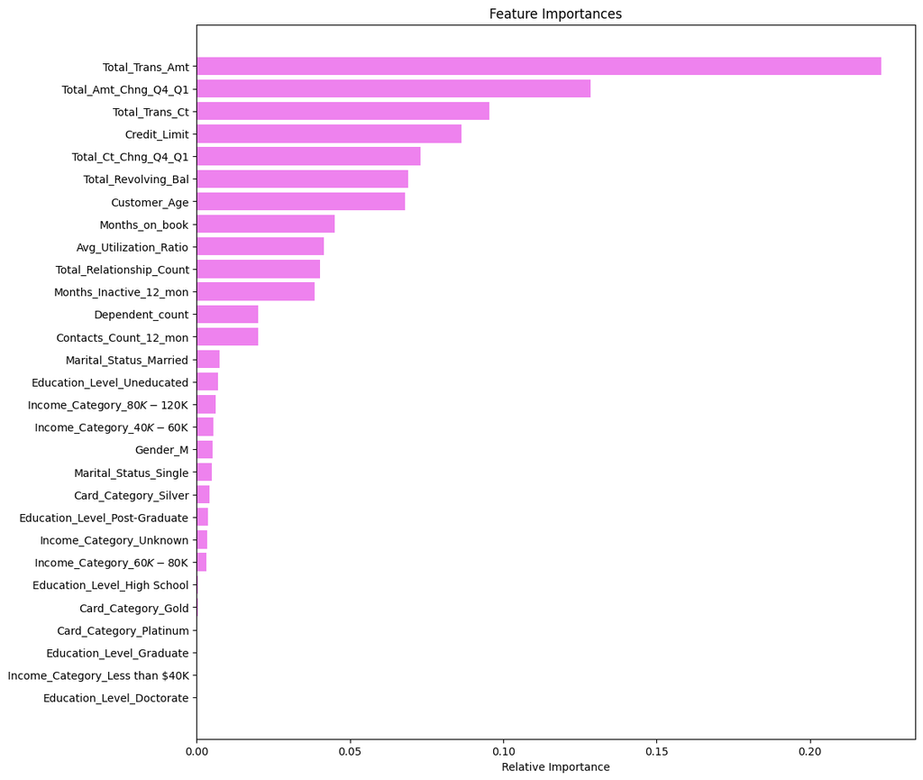

```python
feature_names = X_train.columns
importances = tuned_ab1.feature_importances_
indices = np.argsort(importances)

plt.figure(figsize=(12, 12))
plt.title("Feature Importances")
plt.barh(range(len(indices)), importances[indices], color="violet", align="center")
plt.yticks(range(len(indices)), [feature_names[i] for i in indices])
plt.xlabel("Relative Importance")
plt.show()
```

# Final Recommendations

**Key Objective:** To predict whether a bank customer has the highest possibility of attriting, as well as to identify which segment of customers to focus on more.

**Conclusions:** Our AdaBoost model stood out as the best performing one so far, capable of successfully predicting whether a customer may attrite with 97% accuracy, 89% recall, 91% precision and 90% F1 score.

Recommendations: Further analysis would need to be conducted to help tune and validate the efficacy of our model against unseen data. However the model seems to be performing relatively well against test data, pointing to a good foundation of support for this project.